# Compare H3K27ac enhancer with gene expression (RNAseq)

last changed: 2023-08-29

# Correlation between H3K27ac and RNAseq

## Data processing

First, the data (rlog-transformed DESeq data sets) were loaded for H3K27ac and RNAseq.

```r
> #RNAseq:
> rlog.RNAseq <-
+   readRDS("./../../2_RNAseq/Significance_testing/Data/rlog_RNAseq.rds")
> head(rlog.RNAseq)
```

```
## class: DESeqTransform
## dim: 6 9
## metadata(1): version
## assays(1): ''
## rownames(6): ENSG00000243485 ENSG00000237613 ... ENSG00000239945
##   ENSG00000241599
## rowData names(7): baseMean baseVar ... dispFit rlogIntercept
## colnames(9): Exp1_0h Exp1_05h ... Exp1_4h Exp2_4h
## colData names(6): ID name ... Time sizeFactor
```

```r
> m.RNAseq <- assay(rlog.RNAseq)
> info.RNAseq <- data.frame(colData(rlog.RNAseq))
> paged_table(info.RNAseq)
```

|  | ID | name | condition | replica | Time | sizeFactor |
| --- | --- | --- | --- | --- | --- | --- |
| Exp1_0h | Exp1_0 | Exp1_0 | 0hpi | R1 | 0.0 | 1.0908519 |
| Exp1_05h | Exp1_05h | Exp1_05h | 0.5hpi | R1 | 0.5 | 0.8861148 |
| Exp2_05h | Exp2_05h | Exp2_05h | 0.5hpi | R2 | 0.5 | 0.8545649 |
| Exp1_1h | Exp1_1h | Exp1_1h | 1hpi | R1 | 1.0 | 0.9294310 |
| Exp2_1h | Exp2_1h | Exp2_1h | 1hpi | R2 | 1.0 | 2.8920422 |
| Exp1_2h | Exp1_2h | Exp1_2h | 2hpi | R1 | 2.0 | 0.9800447 |
| Exp2_2h | Exp2_2h | Exp2_2h | 2hpi | R2 | 2.0 | 1.0280833 |
| Exp1_4h | Exp1_4h | Exp1_4h | 4hpi | R1 | 4.0 | 0.6642453 |
| Exp2_4h | Exp2_4h | Exp2_4h | 4hpi | R2 | 4.0 | 0.6961808 |

```r
> m.RNAseq <- m.RNAseq[, info.RNAseq %>% rownames()]
> head(m.RNAseq)
```

```
##                   Exp1_0h  Exp1_05h  Exp2_05h   Exp1_1h   Exp2_1h   Exp1_2h
## ENSG00000243485  0.000000  0.000000  0.000000  0.000000  0.000000  0.000000
## ENSG00000237613  0.000000  0.000000  0.000000  0.000000  0.000000  0.000000
## ENSG00000186092  0.000000  0.000000  0.000000  0.000000  0.000000  0.000000
## ENSG00000238009 -2.088926 -2.088404 -2.088313 -2.088524 -2.090759 -2.088657
## ENSG00000239945  0.000000  0.000000  0.000000  0.000000  0.000000  0.000000
## ENSG00000241599  0.000000  0.000000  0.000000  0.000000  0.000000  0.000000
##                   Exp2_2h   Exp1_4h  Exp2_4h
## ENSG00000243485  0.000000  0.000000  0.00000
## ENSG00000237613  0.000000  0.000000  0.00000
## ENSG00000186092  0.000000  0.000000  0.00000
## ENSG00000238009 -2.088777 -2.087679 -2.08277
## ENSG00000239945  0.000000  0.000000  0.00000
## ENSG00000241599  0.000000  0.000000  0.00000
```

```r
> #H3K27ac:
> rlog.H3ac <-
+   readRDS("./../../1_H3K27ac_peaks/MACS2_broad_peaks/1_LRT/Significance_testing/Data/rlog_H3K27ac_sig.rds")
> head(rlog.H3ac)
```

```
## class: DESeqTransform
## dim: 6 22
## metadata(1): version
## assays(1): ''
## rownames(6): chr1:923270-926516 chr1:1019193-1026163 ...
##   chr1:1693797-1694533 chr1:1777412-1779430
## rowData names(7): baseMean baseVar ... dispFit rlogIntercept
## colnames(22): U2OS31_T0h_Rep1 U2OS31_T0h_Rep2 ... U2OS33_T4h_Rep2
##   U2OS33_T4h_Rep3
## colData names(4): construct replica time sizeFactor
```

```r
> info.H3ac <- data.frame(colData(rlog.H3ac))
> paged_table(info.H3ac)
```

|  | construct | replica | time | sizeFactor |
| --- | --- | --- | --- | --- |
| U2OS31_T0h_Rep1 | U2OS31 | Rep1 | 0 | 0.9713745 |
| U2OS31_T0h_Rep2 | U2OS31 | Rep2 | 0 | 0.9677638 |
| U2OS31_T0h_Rep3 | U2OS31 | Rep3 | 0 | 1.4070125 |
| U2OS31_T1h_Rep1 | U2OS31 | Rep1 | 1 | 1.3427846 |
| U2OS31_T1h_Rep2 | U2OS31 | Rep2 | 1 | 1.3689437 |
| U2OS31_T1h_Rep3 | U2OS31 | Rep3 | 1 | 1.3748857 |
| U2OS31_T2h_Rep1 | U2OS31 | Rep1 | 2 | 0.9648885 |
| U2OS31_T2h_Rep2 | U2OS31 | Rep2 | 2 | 1.3894730 |
| U2OS31_T4h_Rep1 | U2OS31 | Rep1 | 4 | 1.0879097 |
| U2OS31_T4h_Rep2 | U2OS31 | Rep2 | 4 | 1.2114263 |

[output cut: 12 more lines]

```r
> m.H3ac <- assay(rlog.H3ac)
> head(m.H3ac)
```

```
##                      U2OS31_T0h_Rep1 U2OS31_T0h_Rep2 U2OS31_T0h_Rep3
## chr1:923270-926516          7.999335        8.985719        8.334292
## chr1:1019193-1026163       10.176104       10.552625       10.176257
## chr1:1247714-1248873        6.056909        6.133303        6.087146
## chr1:1510763-1513097        8.158436        8.641024        8.316338
## chr1:1693797-1694533        5.855966        6.249061        6.254131
## chr1:1777412-1779430        8.254269        8.532619        8.194564
##                      U2OS31_T1h_Rep1 U2OS31_T1h_Rep2 U2OS31_T1h_Rep3
## chr1:923270-926516          8.984147        9.150024        8.944955
## chr1:1019193-1026163       10.195272       10.614003       10.396865
## chr1:1247714-1248873        5.670621        5.985477        6.047134
## chr1:1510763-1513097        8.001440        8.409950        8.117495
## chr1:1693797-1694533        5.980106        5.659072        5.717397
## chr1:1777412-1779430        8.288444        8.669121        8.251984
##                      U2OS31_T2h_Rep1 U2OS31_T2h_Rep2 U2OS31_T4h_Rep1
## chr1:923270-926516          8.595118        7.913353        8.339156
## chr1:1019193-1026163       10.253510       10.229117       10.107741
## chr1:1247714-1248873        6.025009        6.327132        6.310482
## chr1:1510763-1513097        8.125629        8.327780        8.154818
## chr1:1693797-1694533        5.686861        5.406716        5.496686
## chr1:1777412-1779430        8.239086        8.180811        8.219928
##                      U2OS31_T4h_Rep2 U2OS33_T0h_Rep1 U2OS33_T0h_Rep2
## chr1:923270-926516          7.703591        8.386781        9.347124
## chr1:1019193-1026163       10.050250       10.118744       10.234218
## chr1:1247714-1248873        6.309163        4.995534        4.703969
## chr1:1510763-1513097        8.348846        8.169646        8.498227
## chr1:1693797-1694533        5.570715        5.568621        5.670425
## chr1:1777412-1779430        8.079199        8.246655        8.609543
##                      U2OS33_T0h_Rep3 U2OS33_T1h_Rep1 U2OS33_T1h_Rep2
## chr1:923270-926516          8.631627        9.509342        9.565205
## chr1:1019193-1026163       10.053496       10.395578       10.713748
## chr1:1247714-1248873        5.473339        5.046691        5.117208
## chr1:1510763-1513097        8.056081        8.024688        8.347749
## chr1:1693797-1694533        6.074303        5.866331        5.491292
## chr1:1777412-1779430        8.057408        8.464051        8.869211
##                      U2OS33_T1h_Rep3 U2OS33_T2h_Rep1 U2OS33_T2h_Rep2
## chr1:923270-926516          8.963849        8.769139        8.500228
## chr1:1019193-1026163       10.183106       10.170189       10.067985
## chr1:1247714-1248873        5.168992        4.608407        5.152406
## chr1:1510763-1513097        8.150377        7.964385        8.405097
## chr1:1693797-1694533        5.430248        5.700828        4.943728
## chr1:1777412-1779430        8.296347        8.392284        8.438388
##                      U2OS33_T2h_Rep3 U2OS33_T4h_Rep1 U2OS33_T4h_Rep2
## chr1:923270-926516          8.292179        8.330028        8.059455
## chr1:1019193-1026163        9.812701        9.930633        9.988549
## chr1:1247714-1248873        5.111077        5.404046        5.591879
## chr1:1510763-1513097        8.100840        7.945059        8.204598
## chr1:1693797-1694533        5.203921        5.466183        5.355025
## chr1:1777412-1779430        8.008979        8.080821        8.430147
##                      U2OS33_T4h_Rep3
## chr1:923270-926516          8.103128
## chr1:1019193-1026163        9.748084
## chr1:1247714-1248873        5.471632
## chr1:1510763-1513097        7.902477
## chr1:1693797-1694533        5.242868
## chr1:1777412-1779430        7.985112
```

Since the two experiments have different time points, the matrices need to be filtered for the required time points. Then, the median over the replicates can be calculated. For the H3K27ac the matrix was additionally separated by construct.

```r
> times <- c(0, 1, 2, 4)
>
> # RNAseq:
> m.RNAseq.median <- matrix(data = NA, ncol = 4, nrow = nrow(m.RNAseq))
> rownames(m.RNAseq.median) <- rownames(m.RNAseq)
> colnames(m.RNAseq.median) <- c("T0h", "T1h", "T2h", "T4h")
>
> for (t in 1:4) {
+   ind <- which(info.RNAseq[, "Time"] == times[t])
+   if (t == 1)
+     medians <- m.RNAseq[, ind]
+   else
+     medians <- apply(m.RNAseq[,  ind], 1, median)
+   m.RNAseq.median[, t] <- medians
+ }
>
> head(m.RNAseq.median)
```

```
##                       T0h       T1h       T2h       T4h
## ENSG00000243485  0.000000  0.000000  0.000000  0.000000
## ENSG00000237613  0.000000  0.000000  0.000000  0.000000
## ENSG00000186092  0.000000  0.000000  0.000000  0.000000
## ENSG00000238009 -2.088926 -2.089641 -2.088717 -2.085224
## ENSG00000239945  0.000000  0.000000  0.000000  0.000000
## ENSG00000241599  0.000000  0.000000  0.000000  0.000000
```

```r
> # H3K27ac:
> ind.H3.1 <- which(info.H3ac$construct == "U2OS31")
> ind.H3.3 <- which(info.H3ac$construct == "U2OS33")
>
> m.H3.1ac <- m.H3ac[ ,ind.H3.1]
> m.H3.3ac <- m.H3ac[ ,ind.H3.3]
>
> m.H3.1ac.median <- matrix(data = NA, ncol = 4, nrow = nrow(m.H3.1ac))
> rownames(m.H3.1ac.median) <- rownames(m.H3.1ac)
> colnames(m.H3.1ac.median) <- c("T0h", "T1h", "T2h", "T4h")
>
> m.H3.3ac.median <- m.H3.1ac.median
>
> for (t in 1:4) {
+   t.0.H3.1 <- which(info.H3ac[ind.H3.1, "time"] == times[t])
+   medians <- apply(m.H3.1ac[,  t.0.H3.1], 1, median)
+   m.H3.1ac.median[, t] <- medians
+ }
> head(m.H3.1ac.median)
```

```
##                            T0h       T1h       T2h       T4h
## chr1:923270-926516    8.334292  8.984147  8.254235  8.021373
## chr1:1019193-1026163 10.176257 10.396865 10.241313 10.078995
## chr1:1247714-1248873  6.087146  5.985477  6.176071  6.309823
## chr1:1510763-1513097  8.316338  8.117495  8.226705  8.251832
## chr1:1693797-1694533  6.249061  5.717397  5.546788  5.533701
## chr1:1777412-1779430  8.254269  8.288444  8.209948  8.149564
```

```r
> for (t in 1:4) {
+   t.0.H3.3 <- which(info.H3ac[ind.H3.3, "time"] == times[t])
+   medians <- apply(m.H3.3ac[,  t.0.H3.3], 1, median)
+   m.H3.3ac.median[, t] <- medians
+ }
> head(m.H3.3ac.median)
```

```
##                            T0h       T1h       T2h      T4h
## chr1:923270-926516    8.631627  9.509342  8.500228 8.103128
## chr1:1019193-1026163 10.118744 10.395578 10.067985 9.930633
## chr1:1247714-1248873  4.995534  5.117208  5.111077 5.471632
## chr1:1510763-1513097  8.169646  8.150377  8.100840 7.945059
## chr1:1693797-1694533  5.670425  5.491292  5.203921 5.355025
## chr1:1777412-1779430  8.246655  8.464051  8.392284 8.080821
```

Further, the annotated enhancer list is required and needs to be sorted and filtered to only contain genes/peaks contained in both experiments.

```r
> enhcr.H3ac <- readRDS("./../Enrichment_analysis/Data/Enhancer2gene.rds")
>
> enhcr.H3ac.2 <- lapply(enhcr.H3ac, function(x) {
+   df <- as.data.frame(x)
+   df <- mutate(df,
+                peak = paste0(df$seqnames, ":", df$start, "-", df$end),
+                codeID = paste0(df$symbol, peak))
+   df <- df[order(df$score, decreasing = T), ]
+   df <- df[!duplicated(df$codeID), ]
+   df <- na.omit(df)
+   })
>
> head(enhcr.H3ac.2)
```

```
## $cluster_1
##      seqnames     start       end width strand        name              symbol
## 1180     chr3 146159375 146167574  8200      * GH03J146151               RPS28
## 1216     chr4  41120149  41130753 10605      * GH04J041118               SNHG5
## 69       chr1  47407491  47412859  5369      * GH01J047408             CCDC163
## 1337     chr5  82276151  82279738  3588      * GH05J082276               WDR18
## 82       chr1  64130512  64135085  4574      * GH01J064132               CLHC1
## 333     chr11 111524163 111532954  8792      * GH11J111531              EXOSC6
## 37       chr1  26847932  26850786  2855      * GH01J026847            ATP6AP1L
## 785     chr19   5176448   5178519  2072      * GH19J005176                KRI1
## 349     chr12   7856853   7862520  5668      * GH12J007858          GASK1B-AS1
## 1181     chr3 149297782 149300963  3182      * GH03J149297                RPSA
## 1219     chr4  41120149  41130753 10605      * GH04J041128               SNHG8
## 172      chr1 221995574 221997874  2301      * GH01J221997               CSKMT
## 418     chr12  80777022  80779122  2101      * GH12J080776              HEATR6
```

[output cut: 17269 more lines]

Next, the gene IDs were translated to ENSEMBL IDs and a new data frame was constructed with each cluster annotated.

```r
> # translate symbols into ENSG:
> enhcr.H3ac.ENSG <- lapply(enhcr.H3ac.2, function(x) {
+   sym.ENSG <- bitr(x$symbol, fromType = "SYMBOL", toType = "ENSEMBL", OrgDb = "org.Hs.eg.db")
+   colnames(sym.ENSG) <- c("symbol", "ENSG")
+   x.ENSG <- left_join(x, sym.ENSG, multiple = "first")
+   x.old.ENSG <- x[which(x$symbol %>% str_detect("ENSG") == T), ]
+   x.old <- mutate(x.old.ENSG, ENSG = x.old.ENSG$symbol)
+   output <- rbind(x.ENSG, x.old)
+   out <- output[match(rownames(m.RNAseq.median), output$ENSG), ] %>% na.omit
+ })
>
> # add clusters to data frame
> df.enhcr.H3ac <- list.rbind(enhcr.H3ac.ENSG)
> n.cluster <- rep(c(1, 2, 3, 4),
+                  times = c(nrow(enhcr.H3ac.ENSG$cluster_1),
+                            nrow(enhcr.H3ac.ENSG$cluster_2),
+                            nrow(enhcr.H3ac.ENSG$cluster_3),
+                            nrow(enhcr.H3ac.ENSG$cluster_4)))
> df.enhcr.H3ac <- mutate(df.enhcr.H3ac, cluster = n.cluster)
>
> paged_table(df.enhcr.H3ac)
```

|  | seqnames | start | end | width | strand | name | symbol | score | peak | codeID | ENSG | cluster |
| --- | --- | --- | --- | --- | --- | --- | --- | --- | --- | --- | --- | --- |
| cluster_1.174 | chr1 | 37945475 | 37947753 | 2279 | * | GH01J037944 | C1QTNF12 | 250.665688 | chr1:37945475-37947753 | C1QTNF12chr1:37945475-37947753 | ENSG00000184163 | 1 |
| cluster_1.2791 | chr11 | 41306087 | 41307140 | 1054 | * | GH11J041306 | ENSG00000284699 | 250.665688 | chr11:41306087-41307140 | ENSG00000284699chr11:41306087-41307140 | ENSG00000284699 | 1 |
| cluster_1.91 | chr22 | 28114814 | 28118426 | 3613 | * | GH22J028115 | RCC1 | 262.612300 | chr22:28114814-28118426 | RCC1chr22:28114814-28118426 | ENSG00000180198 | 1 |
| cluster_1.85 | chr5 | 58256648 | 58261930 | 5283 | * | GH05J058261 | TAF12 | 263.980528 | chr5:58256648-58261930 | TAF12chr5:58256648-58261930 | ENSG00000120656 | 1 |
| cluster_1.77 | chr18 | 45805912 | 45807154 | 1243 | * | GH18J045805 | INPP5B | 265.756058 | chr18:45805912-45807154 | INPP5Bchr18:45805912-45807154 | ENSG00000204084 | 1 |
| cluster_1.892 | chr5 | 42893875 | 42894664 | 790 | * | GH05J042894 | ST3GAL3 | 250.665688 | chr5:42893875-42894664 | ST3GAL3chr5:42893875-42894664 | ENSG00000126091 | 1 |
| cluster_1.1226 | chr1 | 24700344 | 24721016 | 20673 | * | GH01J024717 | ARTN | 18.201435 | chr1:24700344-24721016 | ARTNchr1:24700344-24721016 | ENSG00000117407 | 1 |
| cluster_1.140 | chr12 | 88241553 | 88243758 | 2206 | * | GH12J088241 | HECTD3 | 255.533361 | chr12:88241553-88243758 | HECTD3chr12:88241553-88243758 | ENSG00000126107 | 1 |
| cluster_1.21 | chr5 | 81849805 | 81852728 | 2924 | * | GH05J081849 | UROD | 284.634554 | chr5:81849805-81852728 | URODchr5:81849805-81852728 | ENSG00000126088 | 1 |
| cluster_1.3 | chr1 | 47407491 | 47412859 | 5369 | * | GH01J047408 | CCDC163 | 348.805937 | chr1:47407491-47412859 | CCDC163chr1:47407491-47412859 | ENSG00000280670 | 1 |

[output cut: 1842 more lines]

This dataframe was then used to filter the matrices for the overlapping gene - peak pairs.

```r
> m.H3.1ac.both <- m.H3.1ac.median[df.enhcr.H3ac$peak, ]
> m.H3.3ac.both <- m.H3.3ac.median[df.enhcr.H3ac$peak, ]
> m.RNAseq.both <- m.RNAseq.median[df.enhcr.H3ac$ENSG, ]
```

Now we can use the sorted matrices to calculate the correlation between gene expression and enhancer acetylation.

```r
> # H3.1K27ac:
> cor.H3.1ac <- c()
>
> for (i in 1:nrow(m.RNAseq.both)) {
+   curr.corr <- cor(m.H3.1ac.both[i, ], m.RNAseq.both[i, ], method = "pearson")
+   cor.H3.1ac <- c(cor.H3.1ac, curr.corr)
+ }
> head(cor.H3.1ac)
```

```
## [1]  0.8125722  0.1437006 -0.8981119 -0.5468799  0.4171535 -0.8669090
```

```r
> # H3.3K27ac:
> cor.H3.3ac <- c()
>
> for (i in 1:nrow(m.RNAseq.both)) {
+   curr.corr <- cor(m.H3.3ac.both[i, ], m.RNAseq.both[i, ], method = "pearson")
+   cor.H3.3ac <- c(cor.H3.3ac, curr.corr)
+ }
> head(cor.H3.1ac)
```

```
## [1]  0.8125722  0.1437006 -0.8981119 -0.5468799  0.4171535 -0.8669090
```

To plot the correlation by each cluster a suitable data frame was generated.

```r
> cor.H3ac.RNAseq <- data.frame(U2OS31 = cor.H3.1ac,
+                               U2OS33 = cor.H3.3ac,
+                               gene = df.enhcr.H3ac$symbol,
+                               ENSG = df.enhcr.H3ac$ENSG,
+                               GHid = df.enhcr.H3ac$name,
+                               peak = df.enhcr.H3ac$peak,
+                               cluster = df.enhcr.H3ac$cluster,
+                               codeID = df.enhcr.H3ac$codeID)
>
> saveRDS(cor.H3ac.RNAseq, file = "./Data/data.cor.rds")
>
> paged_table(cor.H3ac.RNAseq)
```

| U2OS31 | U2OS33 | gene | ENSG | GHid | peak | cluster | codeID |
| --- | --- | --- | --- | --- | --- | --- | --- |
| 0.812572178 | 0.7161036212 | C1QTNF12 | ENSG00000184163 | GH01J037944 | chr1:37945475-37947753 | 1 | C1QTNF12chr1:37945475-37947753 |
| 0.143700636 | 0.1469810198 | ENSG00000284699 | ENSG00000284699 | GH11J041306 | chr11:41306087-41307140 | 1 | ENSG00000284699chr11:41306087-41307140 |
| -0.898111876 | -0.5715487129 | RCC1 | ENSG00000180198 | GH22J028115 | chr22:28114814-28118426 | 1 | RCC1chr22:28114814-28118426 |
| -0.546879859 | -0.5064760974 | TAF12 | ENSG00000120656 | GH05J058261 | chr5:58256648-58261930 | 1 | TAF12chr5:58256648-58261930 |
| 0.417153512 | -0.3878029664 | INPP5B | ENSG00000204084 | GH18J045805 | chr18:45805912-45807154 | 1 | INPP5Bchr18:45805912-45807154 |
| -0.866909045 | -0.9186476833 | ST3GAL3 | ENSG00000126091 | GH05J042894 | chr5:42893875-42894664 | 1 | ST3GAL3chr5:42893875-42894664 |
| 0.896988988 | 0.7986791611 | ARTN | ENSG00000117407 | GH01J024717 | chr1:24700344-24721016 | 1 | ARTNchr1:24700344-24721016 |
| -0.964794651 | -0.9795940766 | HECTD3 | ENSG00000126107 | GH12J088241 | chr12:88241553-88243758 | 1 | HECTD3chr12:88241553-88243758 |
| -0.850365191 | -0.9518340692 | UROD | ENSG00000126088 | GH05J081849 | chr5:81849805-81852728 | 1 | URODchr5:81849805-81852728 |
| 0.839573917 | 0.8531186247 | CCDC163 | ENSG00000280670 | GH01J047408 | chr1:47407491-47412859 | 1 | CCDC163chr1:47407491-47412859 |

[output cut: 1842 more lines]

Finally, the correlation can be plotted as follows:

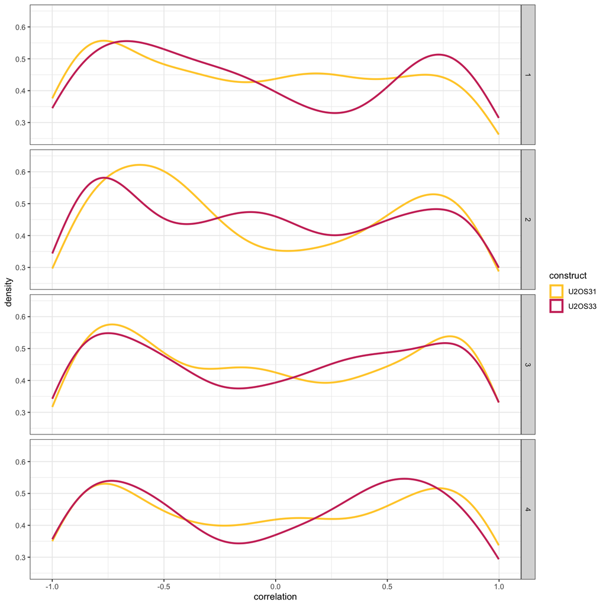

```r
> ggplot(cor.H3ac.RNAseq) +
+   geom_density(aes(x = U2OS31, color = "U2OS31"), linewidth = 1.05) +
+   geom_density(aes(x = U2OS33, color = "U2OS33"), linewidth = 1.05) +
+   scale_color_manual(name = "construct",
+                      breaks = c("U2OS31", "U2OS33"),
+                      values = c("U2OS31" = "#FFCC33", "U2OS33" = "#CC3366")) +
+   labs(x = "correlation") +
+   theme_bw() +
+   facet_grid(rows = cor.H3ac.RNAseq$cluster, scales = "free_y") +
+   coord_cartesian(ylim =  c(0.25, 0.65))
```

## References - packages

- Ahlmann-Eltze C, Hickey P, Pagès H (2023). *MatrixGenerics: S4 Generic Summary Statistic Functions that Operate on Matrix-Like Objects*. doi:10.18129/B9.bioc.MatrixGenerics https://doi.org/10.18129/B9.bioc.MatrixGenerics, R package version 1.12.2, https://bioconductor.org/packages/MatrixGenerics.
- Allaire J, Xie Y, Dervieux C, McPherson J, Luraschi J, Ushey K, Atkins A, Wickham H, Cheng J, Chang W, Iannone R (2023). *rmarkdown: Dynamic Documents for R*. R package version 2.23, https://github.com/rstudio/rmarkdown. Xie Y, Allaire J, Grolemund G (2018). *R Markdown: The Definitive Guide*. Chapman and Hall/CRC, Boca Raton, Florida. ISBN 9781138359338, https://bookdown.org/yihui/rmarkdown. Xie Y, Dervieux C, Riederer E (2020). *R Markdown Cookbook*. Chapman and Hall/CRC, Boca Raton, Florida. ISBN 9780367563837, https://bookdown.org/yihui/rmarkdown-cookbook.
- Arora S, Morgan M, Carlson M, Pagès H (2023). *GenomeInfoDb: Utilities for manipulating chromosome names, including modifying them to follow a particular naming style*. doi:10.18129/B9.bioc.GenomeInfoDb https://doi.org/10.18129/B9.bioc.GenomeInfoDb, R package version 1.36.0, https://bioconductor.org/packages/GenomeInfoDb.
- Bengtsson H (2023). *matrixStats: Functions that Apply to Rows and Columns of Matrices (and to Vectors)*. R package version 1.0.0, https://CRAN.R-project.org/package=matrixStats.
- Grolemund G, Wickham H (2011). “Dates and Times Made Easy with lubridate.” *Journal of Statistical Software*, *40*(3), 1-25. https://www.jstatsoft.org/v40/i03/.
- Huber W, Carey VJ, Gentleman R, Anders S, Carlson M, Carvalho BS, Bravo HC, Davis S, Gatto L, Girke T, Gottardo R, Hahne F, Hansen KD, Irizarry RA, Lawrence M, Love MI, MacDonald J, Obenchain V, Ole’s AK, Pag`es H, Reyes A, Shannon P, Smyth GK, Tenenbaum D, Waldron L, Morgan M (2015). “Orchestrating high-throughput genomic analysis with Bioconductor.” *Nature Methods*, *12*(2), 115-121. http://www.nature.com/nmeth/journal/v12/n2/full/nmeth.3252.html.
- Huber, W., Carey, J. V, Gentleman, R., Anders, S., Carlson, M., Carvalho, S. B, Bravo, C. H, Davis, S., Gatto, L., Girke, T., Gottardo, R., Hahne, F., Hansen, D. K, Irizarry, A. R, Lawrence, M., Love, I. M, MacDonald, J., Obenchain, V., Ole’s, K. A, Pag`es, H., Reyes, A., Shannon, P., Smyth, K. G, Tenenbaum, D., Waldron, L., Morgan, M. (2015). “Orchestrating high-throughput genomic analysis with Bioconductor.” *Nature Methods*, *12*(2), 115-121. http://www.nature.com/nmeth/journal/v12/n2/full/nmeth.3252.html.
- Lawrence M, Huber W, Pagès H, Aboyoun P, Carlson M, Gentleman R, Morgan M, Carey V (2013). “Software for Computing and Annotating Genomic Ranges.” *PLoS Computational Biology*, *9*. doi:10.1371/journal.pcbi.1003118 https://doi.org/10.1371/journal.pcbi.1003118, http://www.ploscompbiol.org/article/info%3Adoi%2F10.1371%2Fjournal.pcbi.1003118.
- Lawrence M, Huber W, Pagès H, Aboyoun P, Carlson M, Gentleman R, Morgan M, Carey V (2013). “Software for Computing and Annotating Genomic Ranges.” *PLoS Computational Biology*, *9*. doi:10.1371/journal.pcbi.1003118 https://doi.org/10.1371/journal.pcbi.1003118, http://www.ploscompbiol.org/article/info%3Adoi%2F10.1371%2Fjournal.pcbi.1003118.
- Lawrence M, Huber W, Pagès H, Aboyoun P, Carlson M, Gentleman R, Morgan M, Carey V (2013). “Software for Computing and Annotating Genomic Ranges.” *PLoS Computational Biology*, *9*. doi:10.1371/journal.pcbi.1003118 https://doi.org/10.1371/journal.pcbi.1003118, http://www.ploscompbiol.org/article/info%3Adoi%2F10.1371%2Fjournal.pcbi.1003118.
- Love MI, Huber W, Anders S (2014). “Moderated estimation of fold change and dispersion for RNA-seq data with DESeq2.” *Genome Biology*, *15*, 550. doi:10.1186/s13059-014-0550-8 https://doi.org/10.1186/s13059-014-0550-8.
- Makowski D, Lüdecke D, Patil I, Thériault R, Ben-Shachar M, Wiernik B (2023). “Automated Results Reporting as a Practical Tool to Improve Reproducibility and Methodological Best Practices Adoption.” *CRAN*. https://easystats.github.io/report/.
- Morgan M, Obenchain V, Hester J, Pagès H (2023). *SummarizedExperiment: SummarizedExperiment container*. doi:10.18129/B9.bioc.SummarizedExperiment https://doi.org/10.18129/B9.bioc.SummarizedExperiment, R package version 1.30.2, https://bioconductor.org/packages/SummarizedExperiment.
- Müller K, Wickham H (2023). *tibble: Simple Data Frames*. R package version 3.2.1, https://CRAN.R-project.org/package=tibble.
- Pagès H, Carlson M, Falcon S, Li N (2023). *AnnotationDbi: Manipulation of SQLite-based annotations in Bioconductor*. doi:10.18129/B9.bioc.AnnotationDbi https://doi.org/10.18129/B9.bioc.AnnotationDbi, R package version 1.62.1, https://bioconductor.org/packages/AnnotationDbi.
- Pagès H, Lawrence M, Aboyoun P (2023). *S4Vectors: Foundation of vector-like and list-like containers in Bioconductor*. doi:10.18129/B9.bioc.S4Vectors https://doi.org/10.18129/B9.bioc.S4Vectors, R package version 0.38.1, https://bioconductor.org/packages/S4Vectors.
- R Core Team (2023). *R: A Language and Environment for Statistical Computing*. R Foundation for Statistical Computing, Vienna, Austria. https://www.R-project.org/.
- Ren K (2021). *rlist: A Toolbox for Non-Tabular Data Manipulation*. R package version 0.4.6.2, https://CRAN.R-project.org/package=rlist.
- Wickham H (2016). *ggplot2: Elegant Graphics for Data Analysis*. Springer-Verlag New York. ISBN 978-3-319-24277-4, https://ggplot2.tidyverse.org.
- Wickham H (2022). *stringr: Simple, Consistent Wrappers for Common String Operations*. R package version 1.5.0, https://CRAN.R-project.org/package=stringr.
- Wickham H (2023). *forcats: Tools for Working with Categorical Variables (Factors)*. R package version 1.0.0, https://CRAN.R-project.org/package=forcats.
- Wickham H, Averick M, Bryan J, Chang W, McGowan LD, François R, Grolemund G, Hayes A, Henry L, Hester J, Kuhn M, Pedersen TL, Miller E, Bache SM, Müller K, Ooms J, Robinson D, Seidel DP, Spinu V, Takahashi K, Vaughan D, Wilke C, Woo K, Yutani H (2019). “Welcome to the tidyverse.” *Journal of Open Source Software*, *4*(43), 1686. doi:10.21105/joss.01686 https://doi.org/10.21105/joss.01686.
- Wickham H, François R, Henry L, Müller K, Vaughan D (2023). *dplyr: A Grammar of Data Manipulation*. R package version 1.1.2, https://CRAN.R-project.org/package=dplyr.
- Wickham H, Henry L (2023). *purrr: Functional Programming Tools*. R package version 1.0.1, https://CRAN.R-project.org/package=purrr.
- Wickham H, Hester J, Bryan J (2023). *readr: Read Rectangular Text Data*. R package version 2.1.4, https://CRAN.R-project.org/package=readr.
- Wickham H, Vaughan D, Girlich M (2023). *tidyr: Tidy Messy Data*. R package version 1.3.0, https://CRAN.R-project.org/package=tidyr.
- Wu T, Hu E, Xu S, Chen M, Guo P, Dai Z, Feng T, Zhou L, Tang W, Zhan L, Fu x, Liu S, Bo X, Yu G (2021). “clusterProfiler 4.0: A universal enrichment tool for interpreting omics data.” *The Innovation*, *2*(3), 100141. doi:10.1016/j.xinn.2021.100141 https://doi.org/10.1016/j.xinn.2021.100141. Yu G, Wang L, Han Y, He Q (2012). “clusterProfiler: an R package for comparing biological themes among gene clusters.” *OMICS: A Journal of Integrative Biology*, *16*(5), 284-287. doi:10.1089/omi.2011.0118 https://doi.org/10.1089/omi.2011.0118.
- Xie Y (2023). *knitr: A General-Purpose Package for Dynamic Report Generation in R*. R package version 1.43, https://yihui.org/knitr/. Xie Y (2015). *Dynamic Documents with R and knitr*, 2nd edition. Chapman and Hall/CRC, Boca Raton, Florida. ISBN 978-1498716963, https://yihui.org/knitr/. Xie Y (2014). “knitr: A Comprehensive Tool for Reproducible Research in R.” In Stodden V, Leisch F, Peng RD (eds.), *Implementing Reproducible Computational Research*. Chapman and Hall/CRC. ISBN 978-1466561595.